# UNICEF Report – Child Mortality Analysis

Produced for Data Analytics and Story Telling (DCU)

Author

Mohammad Anas Rehman

Published

April 27, 2025

# Introduction

*Imagine being born in a country where your chances of surviving past your fifth birthday are 10 times lower than someone else’s — simply because of where you were born.*  
This is the reality for millions of young girls globally. This report analyzes **under-five female mortality** using UNICEF datasets, highlighting not just the numbers, but the human stories behind them.

# Mortality Trends Over Time (Time Series)

While many countries have made impressive gains since 2000, progress has been uneven.  
Countries like **India** and **Bangladesh** show encouraging improvements, reflecting the impact of sustained public health campaigns.  
However, in countries like **Nigeria**, gains have been far more modest — a signal that interventions are not reaching everyone equally.

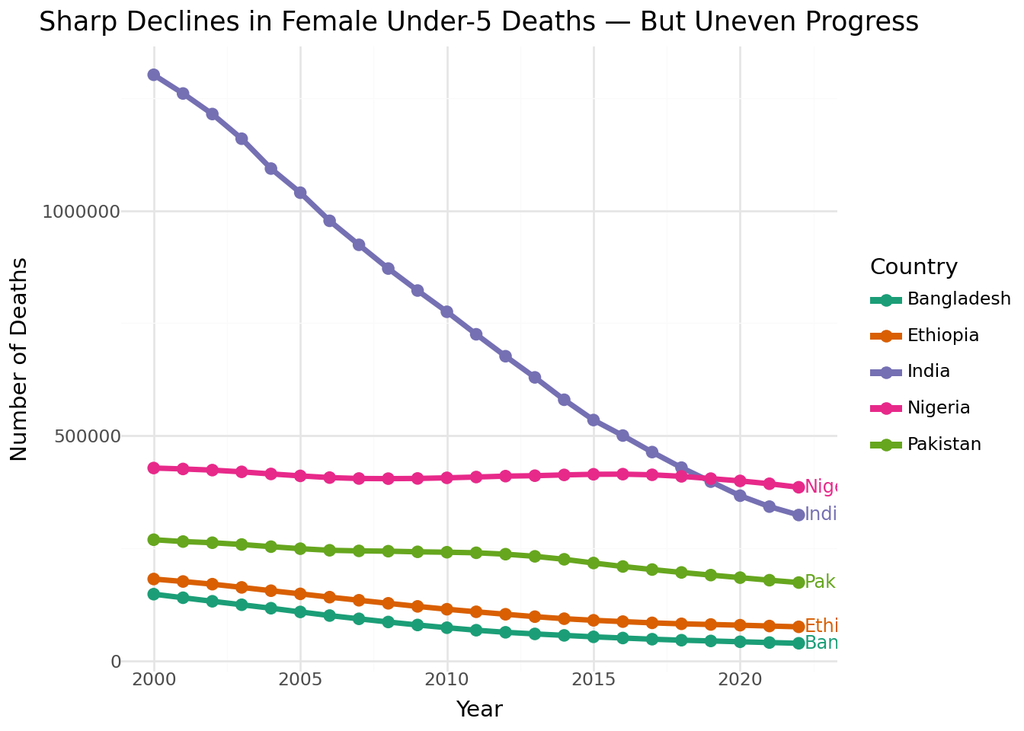

```python
import polars as pl
import pandas as pd
from plotnine import *
import geopandas as gpd
import matplotlib.pyplot as plt

indicator = pl.read_csv("unicef_indicator_1.csv")
metadata = pl.read_csv("unicef_metadata.csv", infer_schema_length=10000, ignore_errors=True)


under5_female = (
    indicator
    .filter(
        (pl.col("indicator") == "Under-five deaths") &
        (pl.col("sex") == "Female") &
        (pl.col("time_period") >= 2000)
    )
    .select([
        pl.col("country"),
        pl.col("alpha_3_code"),
        pl.col("time_period").alias("year"),
        pl.col("obs_value").alias("under_five_deaths")
    ])
)


selected_countries = ["India", "Nigeria", "Pakistan", "Ethiopia", "Bangladesh"]

under5_female_selected = (
    under5_female
    .filter(pl.col("country").is_in(selected_countries))
    .sort(["country", "year"])
)

df_ts = under5_female_selected.to_pandas()

final_year = df_ts["year"].max()
df_ts["label"] = df_ts.apply(lambda row: row["country"] if row["year"] == final_year else "", axis=1)

(
    ggplot(df_ts) +
    aes(x="year", y="under_five_deaths", color="country", group="country") +
    geom_line(size=1.5) +
    geom_point(size=2.5) +
    geom_text(aes(label="label"), ha="left", nudge_x=0.2, size=9) +
    theme_minimal() +
    scale_color_brewer(type="qual", palette="Dark2") +
    labs(
        title="Sharp Declines in Female Under-5 Deaths — But Uneven Progress",
        x="Year",
        y="Number of Deaths",
        color="Country"
    )
)
```

# Top 10 Countries in 2020 (Bar Chart)

This chart answers a critical question: *where is the problem the worst right now?*  
A few countries account for a disproportionately high number of under-five deaths — and tackling the crisis in these areas is essential for moving the global average.

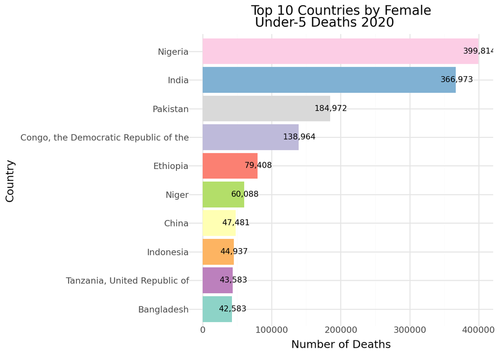

```python
under5_2020 = (
    under5_female
    .filter(pl.col("year") == 2020)
    .sort("under_five_deaths", descending=True)
    .head(10)
)
df_bar = under5_2020.to_pandas()

(
    ggplot(df_bar) +
    aes(x="reorder(country, under_five_deaths)", y="under_five_deaths", fill="country") +
    geom_col(show_legend=False) +
    geom_text(aes(label="under_five_deaths"), nudge_y=1000, size=8, format_string="{:,.0f}") +
    coord_flip() +
    scale_fill_brewer(type="qual", palette="Set3") +
    theme_minimal() +
    labs(
        title="Top 10 Countries by Female\n Under-5 Deaths 2020",
        x="Country",
        y="Number of Deaths"
    )
)
```

# GDP vs Child Mortality (Scatterplot)

Does being a richer country mean fewer child deaths? Generally, yes.  
But this chart also shows **exceptions** — middle-income countries with surprisingly high mortality, and poorer nations that outperform expectations.  
These outliers show the importance of **health systems, governance, and education**, not just GDP.

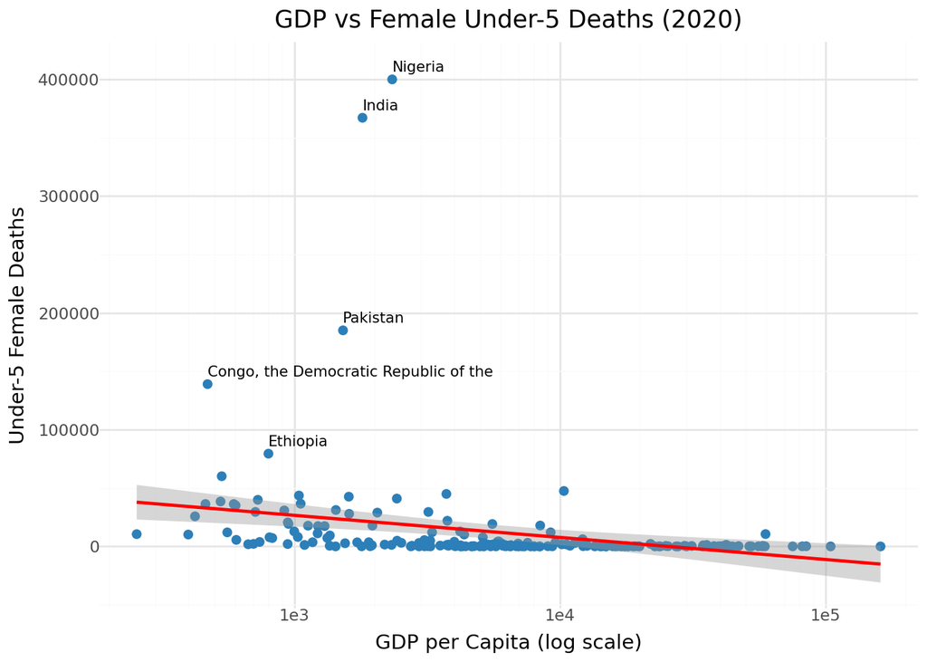

```python
joined = (
    under5_female
    .join(metadata, on=["country", "year"], how="left")
    .filter(pl.col("year") == 2020)
    .select([
        pl.col("country"),
        pl.col("under_five_deaths"),
        pl.col("GDP per capita (constant 2015 US$)").alias("gdp_per_capita")
    ])
    .drop_nulls()
)
df_scatter = joined.to_pandas()

# Identify top 5 countries by death count for labeling
top_countries = df_scatter.nlargest(5, "under_five_deaths")["country"].tolist()
df_scatter["label"] = df_scatter["country"].apply(lambda x: x if x in top_countries else None)


(
    ggplot(df_scatter) +
    aes(x="gdp_per_capita", y="under_five_deaths") +
    geom_point(color="#2c7fb8", size=2) +
    geom_text(aes(label="label"), na_rm=True, nudge_y=10000, size=8, ha="left") +
    geom_smooth(method="lm", color="red", se=True) +
    scale_x_log10() +
    theme_minimal() +
    labs(
        title="GDP vs Female Under-5 Deaths (2020)",
        x="GDP per Capita (log scale)",
        y="Under-5 Female Deaths"
    )
)
```

# Global Distribution (2020) World Map

This map is more than data. It’s a **visual wake-up call**.  
It reveals the stark inequality that persists across regions, with Sub-Saharan Africa and parts of South Asia still facing the highest burden.  
Where a girl is born shouldn’t determine whether she survives.

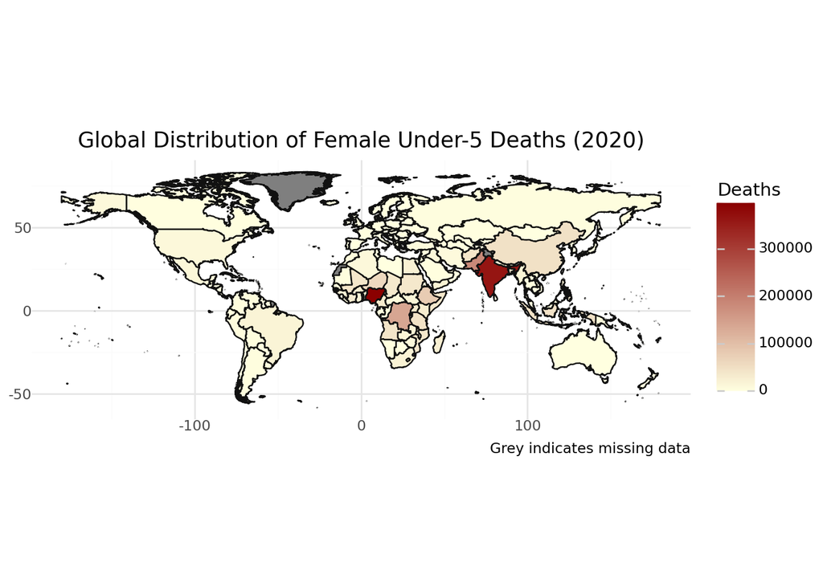

```python
import geopandas as gpd

# Load world boundaries
shape_world = gpd.read_file("https://public.opendatasoft.com/api/explore/v2.1/catalog/datasets/world-administrative-boundaries/exports/shp")



# Used 3-letter country codes for easier merging
under5_map_data = (
    under5_female
    .filter(pl.col("year") == 2020)
    .select(["alpha_3_code", "under_five_deaths"])
    .drop_nulls()
    .to_pandas()
)

map_merged = shape_world.merge(
    under5_map_data,
    left_on="iso3",
    right_on="alpha_3_code",
    how="left"
)

(
    ggplot(map_merged) +
    aes(map_id="iso3", fill="under_five_deaths") +
    geom_map() +
    coord_fixed() +
    scale_fill_gradient(low="lightyellow", high="darkred") +
    theme_minimal() +
    labs(
        title="Global Distribution of Female Under-5 Deaths (2020)",
        fill="Deaths",
        caption="Grey indicates missing data"
    )
)
```

# Conclusion

The story these numbers tell is clear: progress has been made — but we’re not done.  
Every chart here represents not just data points, but lives.  
**Data like this should inform not only dashboards — but decisions.**

The tools exist. The knowledge exists. What remains is urgency.